# Can Statistics Detect Fake Data?

Summarising the pooled family: of 12 indicators, 5 show a significant and practically material deviation, 0 show a significant but small deviation, 5 show no significant deviation, 2 were unsuitable for the test and 0 had insufficient sample.

## 6.6 5.6 Comparison across subsets (year and region)

Per-year subsets: only years with at least 110 eligible values were tested (validity guard).

| Indicator | Years_tested | Years_significant | Median_year_MAD |
| --- | --- | --- | --- |
| AG.LND.TOTL.K2 | 63 | 0 | 0.0098 |
| FI.RES.TOTL.CD | 53 | 0 | 0.0202 |
| NE.EXP.GNFS.CD | 46 | 0 | 0.0195 |
| NE.IMP.GNFS.CD | 46 | 1 | 0.0192 |
| NY.GDP.MKTP.CD | 66 | 0 | 0.0153 |
| NY.GNP.MKTP.CD | 61 | 1 | 0.0165 |
| SP.DYN.LE00.IN | 65 | 65 | 0.1533 |
| SP.DYN.TFRT.IN | 65 | 65 | 0.0483 |
| SP.POP.TOTL | 66 | 0 | 0.0123 |
| USASPEND.CURRENT_TOTAL_VALUE_OF_AWARD | 2 | 2 | 0.0188 |
| USASPEND.FEDERAL_ACTION_OBLIGATION | 2 | 2 | 0.0200 |
| USASPEND.POTENTIAL_TOTAL_VALUE_OF_AWARD | 2 | 2 | 0.0183 |

Per-region subsets of the pooled country-years. Small regions are skipped by the minimum-sample guard.

| Indicator | Region | N | X2 | p_BH | MAD | Flag |
| --- | --- | --- | --- | --- | --- | --- |
| Land area (sq. km) | East Asia & Pacific | 2211 | 144.051 | 1.78e-26 | 0.0253 | Statistical deviation: significant AND practically material |
| Land area (sq. km) | Europe & Central Asia | 2768 | 245.537 | 8.83e-48 | 0.0278 | Statistical deviation: significant AND practically material |
| Land area (sq. km) | Latin America & Caribbean | 2496 | 205.531 | 2.42e-39 | 0.0263 | Statistical deviation: significant AND practically material |
| Land area (sq. km) | Middle East & North Africa | 1449 | 143.647 | 2.14e-26 | 0.0211 | Statistical deviation: significant AND practically material |
| Land area (sq. km) | North America | 189 | 945.693 | 1.26e-197 | 0.1831 | Not assessed - unsuitable data |
| Land area (sq. km) | South Asia | 378 | 188.846 | 7.76e-36 | 0.0557 | Not assessed - unsuitable data |
| Land area (sq. km) | Sub-Saharan Africa | 2858 | 228.632 | 3.26e-44 | 0.0232 | Statistical deviation: significant AND practically material |
| Total reserves incl. gold (current USD) | East Asia & Pacific | 1311 | 29.937 | 0.0008 | 0.0111 | Statistical deviation: significant AND practically material |
| Total reserves incl. gold (current USD) | Europe & Central Asia | 2242 | 9.250 | 0.6565 | 0.0064 | No significant deviation detected |
| Total reserves incl. gold (current USD) | Latin America & Caribbean | 2022 | 2.539 | 0.9971 | 0.0032 | No significant deviation detected |
| Total reserves incl. gold (current USD) | Middle East & North Africa | 1297 | 36.350 | 5.52e-05 | 0.0168 | Statistical deviation: significant AND practically material |
| Total reserves incl. gold (current USD) | North America | 132 | 14.455 | 0.1978 | 0.0334 | No significant deviation detected |
| Total reserves incl. gold (current USD) | South Asia | 344 | 15.783 | 0.1336 | 0.0161 | No significant deviation detected |
| Total reserves incl. gold (current USD) | Sub-Saharan Africa | 2116 | 26.395 | 0.0031 | 0.0101 | Statistical deviation: significant AND practically material |
| Exports of goods and services (current USD) | East Asia & Pacific | 1488 | 6.595 | 0.9220 | 0.0052 | No significant deviation detected |
| Exports of goods and services (current USD) | Europe & Central Asia | 2238 | 4.801 | 0.9971 | 0.0035 | No significant deviation detected |
| Exports of goods and services (current USD) | Latin America & Caribbean | 1523 | 16.714 | 0.1006 | 0.0103 | No significant deviation detected |
| Exports of goods and services (current USD) | Middle East & North Africa | 1109 | 23.528 | 0.0092 | 0.0119 | Statistical deviation: significant AND practically material |
| Exports of goods and services (current USD) | North America | 135 | 17.473 | 0.0787 | 0.0336 | No significant deviation detected |
| Exports of goods and services (current USD) | South Asia | 310 | 11.638 | 0.4117 | 0.0155 | No significant deviation detected |
| Exports of goods and services (current USD) | Sub-Saharan Africa | 2221 | 10.879 | 0.4863 | 0.0063 | No significant deviation detected |
| Imports of goods and services (current USD) | East Asia & Pacific | 1488 | 12.683 | 0.3254 | 0.0085 | No significant deviation detected |
| Imports of goods and services (current USD) | Europe & Central Asia | 2238 | 14.540 | 0.1941 | 0.0056 | No significant deviation detected |
| Imports of goods and services (current USD) | Latin America & Caribbean | 1532 | 21.630 | 0.0183 | 0.0114 | Statistical deviation: significant AND practically material |
| Imports of goods and services (current USD) | Middle East & North Africa | 1109 | 15.718 | 0.1359 | 0.0114 | No significant deviation detected |
| Imports of goods and services (current USD) | North America | 135 | 13.249 | 0.2787 | 0.0275 | No significant deviation detected |
| Imports of goods and services (current USD) | South Asia | 310 | 9.196 | 0.6616 | 0.0151 | No significant deviation detected |
| Imports of goods and services (current USD) | Sub-Saharan Africa | 2221 | 12.050 | 0.3752 | 0.0073 | No significant deviation detected |
| GDP (current USD) | East Asia & Pacific | 1969 | 10.195 | 0.5655 | 0.0072 | No significant deviation detected |
| GDP (current USD) | Europe & Central Asia | 2737 | 28.154 | 0.0015 | 0.0076 | Statistical deviation: significant AND practically material |
| GDP (current USD) | Latin America & Caribbean | 2301 | 16.365 | 0.1123 | 0.0070 | No significant deviation detected |
| GDP (current USD) | Middle East & North Africa | 1299 | 49.448 | 2.04e-07 | 0.0137 | Statistical deviation: significant AND practically material |
| GDP (current USD) | North America | 197 | 22.213 | 0.0149 | 0.0249 | Statistical deviation: significant AND practically material |
| GDP (current USD) | South Asia | 376 | 11.129 | 0.4637 | 0.0174 | No significant deviation detected |
| GDP (current USD) | Sub-Saharan Africa | 2885 | 21.776 | 0.0175 | 0.0087 | Statistical deviation: significant AND practically material |
| GNI (current USD) | East Asia & Pacific | 1877 | 6.835 | 0.9034 | 0.0057 | No significant deviation detected |
| GNI (current USD) | Europe & Central Asia | 2561 | 18.315 | 0.0601 | 0.0067 | No significant deviation detected |
| GNI (current USD) | Latin America & Caribbean | 2199 | 23.404 | 0.0096 | 0.0097 | Statistical deviation: significant AND practically material |
| GNI (current USD) | Middle East & North Africa | 1298 | 24.519 | 0.0063 | 0.0115 | Statistical deviation: significant AND practically material |
| GNI (current USD) | North America | 147 | 17.183 | 0.0864 | 0.0275 | No significant deviation detected |
| GNI (current USD) | South Asia | 363 | 10.942 | 0.4815 | 0.0179 | No significant deviation detected |
| GNI (current USD) | Sub-Saharan Africa | 2789 | 22.257 | 0.0147 | 0.0091 | Statistical deviation: significant AND practically material |
| Life expectancy at birth (years) | East Asia & Pacific | 2405 | 8513.330 | 0.00e+00 | 0.1534 | Not assessed - unsuitable data |
| Life expectancy at birth (years) | Europe & Central Asia | 3770 | 22442.398 | 0.00e+00 | 0.1740 | Not assessed - unsuitable data |
| Life expectancy at birth (years) | Latin America & Caribbean | 2730 | 14858.939 | 0.00e+00 | 0.1683 | Not assessed - unsuitable data |
| Life expectancy at birth (years) | Middle East & North Africa | 1461 | 4588.811 | 0.00e+00 | 0.1399 | Not assessed - unsuitable data |
| Life expectancy at birth (years) | North America | 195 | 1838.145 | 0.00e+00 | 0.1831 | Not assessed - unsuitable data |
| Life expectancy at birth (years) | South Asia | 390 | 937.790 | 5.94e-196 | 0.1434 | Not assessed - unsuitable data |
| Life expectancy at birth (years) | Sub-Saharan Africa | 3120 | 7648.700 | 0.00e+00 | 0.1434 | Not assessed - unsuitable data |
| Fertility rate, total (births per woman) | East Asia & Pacific | 2405 | 572.812 | 1.28e-117 | 0.0491 | Not assessed - unsuitable data |
| Fertility rate, total (births per woman) | Europe & Central Asia | 3768 | 2375.127 | 0.00e+00 | 0.0868 | Not assessed - unsuitable data |
| Fertility rate, total (births per woman) | Latin America & Caribbean | 2730 | 841.062 | 2.88e-175 | 0.0522 | Not assessed - unsuitable data |
| Fertility rate, total (births per woman) | Middle East & North Africa | 1465 | 732.232 | 7.25e-152 | 0.0631 | Not assessed - unsuitable data |
| Fertility rate, total (births per woman) | North America | 195 | 187.883 | 1.23e-35 | 0.0968 | Not assessed - unsuitable data |
| Fertility rate, total (births per woman) | South Asia | 390 | 242.311 | 4.22e-47 | 0.0728 | Not assessed - unsuitable data |
| Fertility rate, total (births per woman) | Sub-Saharan Africa | 3120 | 6683.712 | 0.00e+00 | 0.1268 | Not assessed - unsuitable data |
| Population, total | East Asia & Pacific | 2442 | 51.749 | 7.47e-08 | 0.0123 | Statistical deviation: significant AND practically material |
| Population, total | Europe & Central Asia | 3828 | 237.681 | 4.00e-46 | 0.0242 | Statistical deviation: significant AND practically material |
| Population, total | Latin America & Caribbean | 2772 | 31.733 | 0.0004 | 0.0087 | Statistical deviation: significant AND practically material |
| Population, total | Middle East & North Africa | 1488 | 29.941 | 0.0008 | 0.0129 | Statistical deviation: significant AND practically material |
| Population, total | North America | 198 | 151.525 | 4.97e-28 | 0.0948 | Statistical deviation: significant AND practically material |
| Population, total | South Asia | 396 | 60.848 | 1.35e-09 | 0.0397 | Statistical deviation: significant AND practically material |
| Population, total | Sub-Saharan Africa | 3168 | 26.191 | 0.0033 | 0.0080 | Statistical deviation: significant AND practically material |
| USASpending current_total_value_of_award (usaspending.csv) | Department of Veterans Affairs | 110044 | 4409.851 | 0.00e+00 | 0.0194 | Statistical deviation: significant AND practically material |
| USASpending federal_action_obligation (usaspending.csv) | Department of Veterans Affairs | 101381 | 4663.333 | 0.00e+00 | 0.0207 | Statistical deviation: significant AND practically material |
| USASpending potential_total_value_of_award (usaspending.csv) | Department of Veterans Affairs | 110253 | 4210.003 | 0.00e+00 | 0.0189 | Statistical deviation: significant AND practically material |

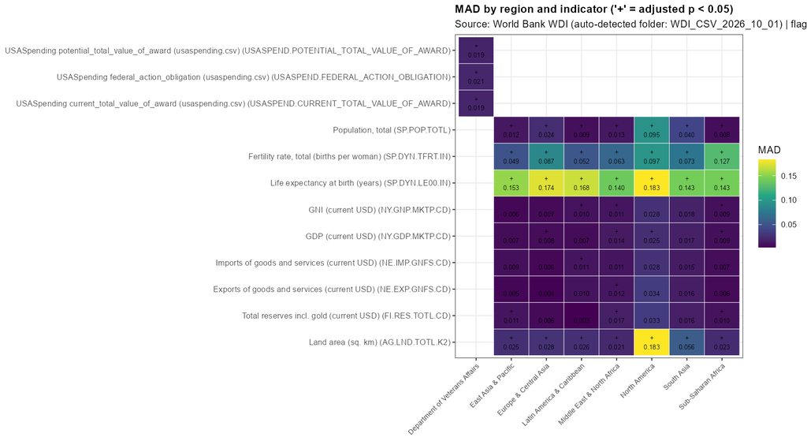

MAD by region and indicator; ‘+’ marks subsets whose BH-adjusted p-value is below alpha.

## 6.7 5.7 Extended digit classes

The first-two-digit test (df = 89) and the second-digit test (df = 9) share the same validity logic. They are reported only when valid, and because their class probabilities are far smaller they need much larger samples.

Extended digit tests on the pooled country-years. ‘Not run’ rows (X2 and p shown as ‘-’) are the validity guard working: no invalid p-value is reported.

| Indicator | Digits | N | df | X2 | p_BH_raw | Tier | MAD | Min_N_reliable |
| --- | --- | --- | --- | --- | --- | --- | --- | --- |
| Land area (sq. km) | first2 | 12349 | 89 | 5287.009 | 0.00e+00 | Reliable | 0.00561 | 1146 |
| Total reserves incl. gold (current USD) | first2 | 9464 | 89 | 125.733 | 0.0063 | Reliable | 0.00099 | 1146 |
| Exports of goods and services (current USD) | first2 | 9024 | 89 | 82.471 | 0.6742 | Reliable | 0.00086 | 1146 |
| Imports of goods and services (current USD) | first2 | 9033 | 89 | 84.304 | 0.6210 | Reliable | 0.00083 | 1146 |
| GDP (current USD) | first2 | 11764 | 89 | 76.575 | 0.8233 | Reliable | 0.00066 | 1146 |
| GNI (current USD) | first2 | 11234 | 89 | 101.276 | 0.1761 | Reliable | 0.00081 | 1146 |
| Life expectancy at birth (years) | first2 | 14071 | 89 | 48575.479 | 0.00e+00 | Reliable | 0.01470 | 1146 |
| Fertility rate, total (births per woman) | first2 | 14073 | 89 | 4157.626 | 0.00e+00 | Reliable | 0.00461 | 1146 |
| Population, total | first2 | 14292 | 89 | 461.839 | 1.03e-51 | Reliable | 0.00150 | 1146 |
| USASpending current_total_value_of_award (usaspending.csv) | first2 | 110044 | 89 | 5310.660 | 0.00e+00 | Reliable | 0.00205 | 1146 |
| USASpending federal_action_obligation (usaspending.csv) | first2 | 101381 | 89 | 6120.479 | 0.00e+00 | Reliable | 0.00234 | 1146 |
| USASpending potential_total_value_of_award (usaspending.csv) | first2 | 110253 | 89 | 5119.233 | 0.00e+00 | Reliable | 0.00204 | 1146 |
| Land area (sq. km) | second | 12349 | 9 | 661.988 | 1.02e-136 | Reliable | 0.01830 | 59 |
| Total reserves incl. gold (current USD) | second | 9464 | 9 | 19.772 | 0.0194 | Reliable | 0.00398 | 59 |
| Exports of goods and services (current USD) | second | 9024 | 9 | 13.047 | 0.1605 | Reliable | 0.00312 | 59 |
| Imports of goods and services (current USD) | second | 9033 | 9 | 5.885 | 0.7514 | Reliable | 0.00226 | 59 |
| GDP (current USD) | second | 11764 | 9 | 8.895 | 0.4470 | Reliable | 0.00223 | 59 |
| GNI (current USD) | second | 11234 | 9 | 6.595 | 0.6792 | Reliable | 0.00187 | 59 |
| Life expectancy at birth (years) | second | 14071 | 9 | 46.725 | 4.42e-07 | Reliable | 0.00466 | 59 |
| Fertility rate, total (births per woman) | second | 14073 | 9 | 247.502 | 3.36e-48 | Reliable | 0.01154 | 59 |
| Population, total | second | 14292 | 9 | 49.158 | 1.55e-07 | Reliable | 0.00487 | 59 |
| USASpending current_total_value_of_award (usaspending.csv) | second | 110044 | 9 | 425.351 | 5.30e-86 | Reliable | 0.00547 | 59 |
| USASpending federal_action_obligation (usaspending.csv) | second | 101381 | 9 | 1005.261 | 1.27e-210 | Reliable | 0.00797 | 59 |
| USASpending potential_total_value_of_award (usaspending.csv) | second | 110253 | 9 | 380.373 | 2.10e-76 | Reliable | 0.00515 | 59 |

# 7 6. Controlled synthetic manipulation experiment

This part is **entirely synthetic** (30 replicates per cell). It measures how the first-digit test behaves when a known fraction of records is altered. The control sample is values drawn from $10^{U(0,6)}$, which conforms to Benford’s Law. Three manipulations are applied to a **copy** of the control: round-number substitution, leading-digit bias towards digits 5-9, and a multiplicative partial alteration (0.8-1.2x) that is deliberately hard to detect. The true alteration rate is stored in its own column and never mixed with the statistical results.

Detection rate = proportion of replicates with p < alpha. At 0% alteration this is the empirical type-I error rate; it is reported as observed and is not claimed to equal alpha exactly.

| Manipulation | True_rate | Replicates | Mean_MAD | Median_MAD | Mean_X2 | Detection_rate | SE |
| --- | --- | --- | --- | --- | --- | --- | --- |
| leading_digit_bias | 0% | 30 | 0.0043 | 0.0043 | 4.84 | 0.000 | 0.000 |
| leading_digit_bias | 5% | 30 | 0.0100 | 0.0100 | 23.74 | 1.000 | 0.000 |
| leading_digit_bias | 10% | 30 | 0.0177 | 0.0178 | 66.85 | 1.000 | 0.000 |
| leading_digit_bias | 20% | 30 | 0.0331 | 0.0330 | 224.78 | 1.000 | 0.000 |
| leading_digit_bias | 30% | 30 | 0.0485 | 0.0484 | 478.51 | 1.000 | 0.000 |
| leading_digit_bias | 50% | 30 | 0.0787 | 0.0788 | 1264.57 | 1.000 | 0.000 |
| partial_alteration | 0% | 30 | 0.0043 | 0.0043 | 4.84 | 0.000 | 0.000 |
| partial_alteration | 5% | 30 | 0.0044 | 0.0044 | 5.05 | 0.000 | 0.000 |
| partial_alteration | 10% | 30 | 0.0046 | 0.0045 | 5.56 | 0.000 | 0.000 |
| partial_alteration | 20% | 30 | 0.0047 | 0.0047 | 6.06 | 0.000 | 0.000 |
| partial_alteration | 30% | 30 | 0.0047 | 0.0046 | 6.53 | 0.000 | 0.000 |
| partial_alteration | 50% | 30 | 0.0048 | 0.0048 | 6.52 | 0.000 | 0.000 |
| round_number | 0% | 30 | 0.0043 | 0.0043 | 4.84 | 0.000 | 0.000 |
| round_number | 5% | 30 | 0.0070 | 0.0069 | 13.12 | 0.167 | 0.068 |
| round_number | 10% | 30 | 0.0105 | 0.0107 | 39.75 | 1.000 | 0.000 |
| round_number | 20% | 30 | 0.0201 | 0.0199 | 149.04 | 1.000 | 0.000 |
| round_number | 30% | 30 | 0.0296 | 0.0295 | 323.76 | 1.000 | 0.000 |
| round_number | 50% | 30 | 0.0490 | 0.0493 | 896.98 | 1.000 | 0.000 |

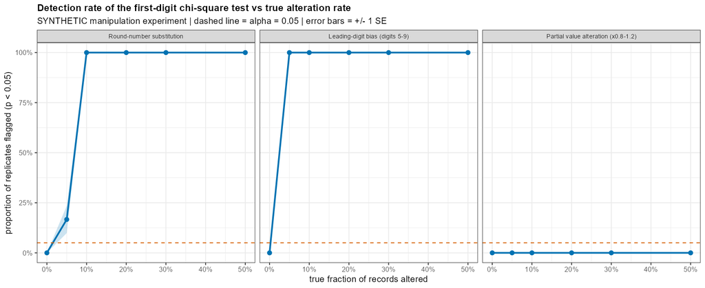

Detection rate versus true alteration rate (SYNTHETIC experiment).

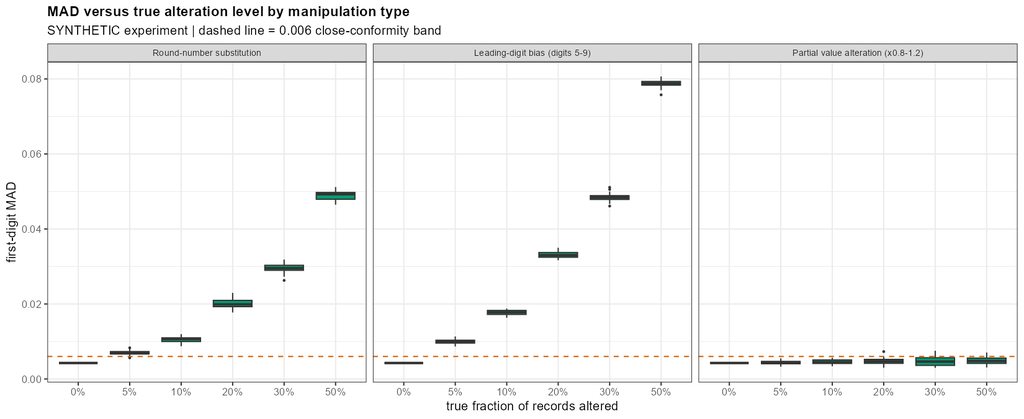

MAD versus true alteration level by manipulation type (SYNTHETIC experiment).

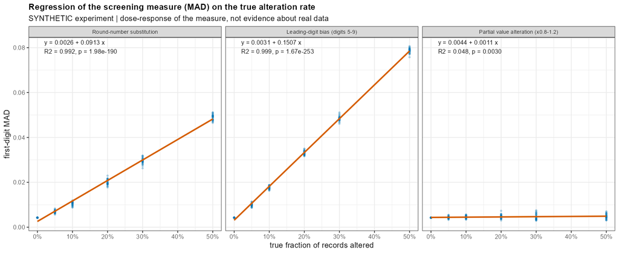

Regression of MAD on the true alteration rate (SYNTHETIC): the dose-response of the screening measure.

## 7.1 6.1 One-way ANOVA of MAD on the alteration level (BMAT202P Experiment 11)

Unit of analysis: one simulated replicate. Response = MAD, factor = alteration level, separately for each manipulation type (completely randomised design). Normality of the residuals is checked with Shapiro-Wilk and homogeneity of variance with Bartlett’s test; when those assumptions are clearly violated, Kruskal-Wallis and a pairwise Wilcoxon (Holm) follow-up are reported and used.

ANOVA, assumption checks and the non-parametric alternative (SYNTHETIC experiment).

| Manipulation | Test | Statistic | df | df2 | p_value |
| --- | --- | --- | --- | --- | --- |
| round_number | one-way ANOVA (MAD ~ alteration level) | 9074.946 | 5 | 174 | 2.71e-208 |
| round_number | Shapiro-Wilk normality of ANOVA residuals | 0.978 | - | - | 0.0054 |
| round_number | Bartlett test of equal variances | Inf | 5 | - | 0.00e+00 |
| round_number | Kruskal-Wallis rank test (non-parametric alternative) | 174.852 | 5 | - | 6.72e-36 |
| round_number | Pairwise Wilcoxon post-hoc (Holm adjusted) | - | - | - | 7.11e-15 |
| round_number | Pairwise Wilcoxon post-hoc (Holm adjusted) | - | - | - | 7.11e-15 |
| round_number | Pairwise Wilcoxon post-hoc (Holm adjusted) | - | - | - | -2.31e-14 |
| round_number | Pairwise Wilcoxon post-hoc (Holm adjusted) | - | - | - | -3.11e-15 |
| round_number | Pairwise Wilcoxon post-hoc (Holm adjusted) | - | - | - | -2.13e-14 |
| round_number | Pairwise Wilcoxon post-hoc (Holm adjusted) | - | - | - | -4.66e-14 |
| round_number | Pairwise Wilcoxon post-hoc (Holm adjusted) | - | - | - | -4.35e-14 |
| round_number | Pairwise Wilcoxon post-hoc (Holm adjusted) | - | - | - | -7.99e-15 |
| round_number | Pairwise Wilcoxon post-hoc (Holm adjusted) | - | - | - | 8.88e-16 |
| round_number | Pairwise Wilcoxon post-hoc (Holm adjusted) | - | - | - | -1.95e-14 |
| round_number | Pairwise Wilcoxon post-hoc (Holm adjusted) | - | - | - | -2.66e-15 |
| round_number | Pairwise Wilcoxon post-hoc (Holm adjusted) | - | - | - | 1.33e-15 |
| round_number | Pairwise Wilcoxon post-hoc (Holm adjusted) | - | - | - | -1.78e-14 |
| round_number | Pairwise Wilcoxon post-hoc (Holm adjusted) | - | - | - | -2.22e-15 |
| round_number | Pairwise Wilcoxon post-hoc (Holm adjusted) | - | - | - | -7.11e-15 |
| leading_digit_bias | one-way ANOVA (MAD ~ alteration level) | 36402.407 | 5 | 174 | 1.14e-260 |
| leading_digit_bias | Shapiro-Wilk normality of ANOVA residuals | 0.971 | - | - | 0.0009 |
| leading_digit_bias | Bartlett test of equal variances | Inf | 5 | - | 0.00e+00 |
| leading_digit_bias | Kruskal-Wallis rank test (non-parametric alternative) | 174.860 | 5 | - | 6.70e-36 |
| leading_digit_bias | Pairwise Wilcoxon post-hoc (Holm adjusted) | - | - | - | -4.88e-15 |
| leading_digit_bias | Pairwise Wilcoxon post-hoc (Holm adjusted) | - | - | - | 9.77e-15 |
| leading_digit_bias | Pairwise Wilcoxon post-hoc (Holm adjusted) | - | - | - | 9.77e-15 |
| leading_digit_bias | Pairwise Wilcoxon post-hoc (Holm adjusted) | - | - | - | -6.66e-14 |
| leading_digit_bias | Pairwise Wilcoxon post-hoc (Holm adjusted) | - | - | - | 0.00e+00 |
| leading_digit_bias | Pairwise Wilcoxon post-hoc (Holm adjusted) | - | - | - | 1.55e-15 |
| leading_digit_bias | Pairwise Wilcoxon post-hoc (Holm adjusted) | - | - | - | -4.44e-15 |
| leading_digit_bias | Pairwise Wilcoxon post-hoc (Holm adjusted) | - | - | - | 1.55e-15 |
| leading_digit_bias | Pairwise Wilcoxon post-hoc (Holm adjusted) | - | - | - | -1.87e-14 |
| leading_digit_bias | Pairwise Wilcoxon post-hoc (Holm adjusted) | - | - | - | -4.00e-15 |
| leading_digit_bias | Pairwise Wilcoxon post-hoc (Holm adjusted) | - | - | - | -1.73e-14 |
| leading_digit_bias | Pairwise Wilcoxon post-hoc (Holm adjusted) | - | - | - | 9.77e-15 |
| leading_digit_bias | Pairwise Wilcoxon post-hoc (Holm adjusted) | - | - | - | 9.77e-15 |
| leading_digit_bias | Pairwise Wilcoxon post-hoc (Holm adjusted) | - | - | - | -1.07e-14 |
| leading_digit_bias | Pairwise Wilcoxon post-hoc (Holm adjusted) | - | - | - | 1.55e-15 |
| partial_alteration | one-way ANOVA (MAD ~ alteration level) | 2.194 | 5 | 174 | 0.0570 |
| partial_alteration | Shapiro-Wilk normality of ANOVA residuals | 0.957 | - | - | 2.56e-05 |
| partial_alteration | Bartlett test of equal variances | Inf | 5 | - | 0.00e+00 |
| partial_alteration | Kruskal-Wallis rank test (non-parametric alternative) | 13.060 | 5 | - | 0.0228 |
| partial_alteration | Pairwise Wilcoxon post-hoc (Holm adjusted) | - | - | - | 1.0000 |
| partial_alteration | Pairwise Wilcoxon post-hoc (Holm adjusted) | - | - | - | 0.0099 |
| partial_alteration | Pairwise Wilcoxon post-hoc (Holm adjusted) | - | - | - | 0.0099 |
| partial_alteration | Pairwise Wilcoxon post-hoc (Holm adjusted) | - | - | - | 1.0000 |
| partial_alteration | Pairwise Wilcoxon post-hoc (Holm adjusted) | - | - | - | 0.0099 |
| partial_alteration | Pairwise Wilcoxon post-hoc (Holm adjusted) | - | - | - | 1.0000 |
| partial_alteration | Pairwise Wilcoxon post-hoc (Holm adjusted) | - | - | - | 0.8838 |
| partial_alteration | Pairwise Wilcoxon post-hoc (Holm adjusted) | - | - | - | 1.0000 |
| partial_alteration | Pairwise Wilcoxon post-hoc (Holm adjusted) | - | - | - | 0.6613 |
| partial_alteration | Pairwise Wilcoxon post-hoc (Holm adjusted) | - | - | - | 1.0000 |
| partial_alteration | Pairwise Wilcoxon post-hoc (Holm adjusted) | - | - | - | 1.0000 |
| partial_alteration | Pairwise Wilcoxon post-hoc (Holm adjusted) | - | - | - | 1.0000 |
| partial_alteration | Pairwise Wilcoxon post-hoc (Holm adjusted) | - | - | - | 1.0000 |
| partial_alteration | Pairwise Wilcoxon post-hoc (Holm adjusted) | - | - | - | 1.0000 |
| partial_alteration | Pairwise Wilcoxon post-hoc (Holm adjusted) | - | - | - | 1.0000 |

Post-hoc comparisons (only the significant ones are listed):

- round_number: 0.05 vs 0 (p = 7.11e-15)
- round_number: 0.1 vs 0 (p = 7.11e-15)
- round_number: 0.2 vs 0 (p = -2.31e-14)
- round_number: 0.3 vs 0 (p = -3.11e-15)
- round_number: 0.5 vs 0 (p = -2.13e-14)
- round_number: 0.1 vs 0.05 (p = -4.66e-14)
- round_number: 0.2 vs 0.05 (p = -4.35e-14)
- round_number: 0.3 vs 0.05 (p = -7.99e-15)
- round_number: 0.5 vs 0.05 (p = 8.88e-16)
- round_number: 0.2 vs 0.1 (p = -1.95e-14)
- round_number: 0.3 vs 0.1 (p = -2.66e-15)
- round_number: 0.5 vs 0.1 (p = 1.33e-15)
- round_number: 0.3 vs 0.2 (p = -1.78e-14)
- round_number: 0.5 vs 0.2 (p = -2.22e-15)
- round_number: 0.5 vs 0.3 (p = -7.11e-15)
- leading_digit_bias: 0.05 vs 0 (p = -4.88e-15)
- leading_digit_bias: 0.1 vs 0 (p = 9.77e-15)
- leading_digit_bias: 0.2 vs 0 (p = 9.77e-15)
- leading_digit_bias: 0.3 vs 0 (p = -6.66e-14)
- leading_digit_bias: 0.5 vs 0 (p = 0.00e+00)
- leading_digit_bias: 0.1 vs 0.05 (p = 1.55e-15)
- leading_digit_bias: 0.2 vs 0.05 (p = -4.44e-15)
- leading_digit_bias: 0.3 vs 0.05 (p = 1.55e-15)
- leading_digit_bias: 0.5 vs 0.05 (p = -1.87e-14)
- leading_digit_bias: 0.2 vs 0.1 (p = -4.00e-15)
- leading_digit_bias: 0.3 vs 0.1 (p = -1.73e-14)
- leading_digit_bias: 0.5 vs 0.1 (p = 9.77e-15)
- leading_digit_bias: 0.3 vs 0.2 (p = 9.77e-15)
- leading_digit_bias: 0.5 vs 0.2 (p = -1.07e-14)
- leading_digit_bias: 0.5 vs 0.3 (p = 1.55e-15)
- partial_alteration: 0.1 vs 0 (p = 0.0099)
- partial_alteration: 0.2 vs 0 (p = 0.0099)
- partial_alteration: 0.5 vs 0 (p = 0.0099)

33 of 45 post-hoc comparisons are significant at alpha = 0.05.

## 7.2 6.2 Regression and correlation of MAD on the true alteration rate (BMAT202P Experiment 3)

Simple linear regression of MAD on the true alteration rate, plus Pearson correlation (SYNTHETIC).

| Manipulation | n | Intercept | Slope | Slope_SE | R_squared | F | df_1 | df_2 | p_value | Pearson_r | Pearson_p |
| --- | --- | --- | --- | --- | --- | --- | --- | --- | --- | --- | --- |
| round_number | 180 | 0.00257 | 0.0913 | 0.00060 | 0.992 | 23166.93 | 1 | 178 | 1.98e-190 | 0.996 | 1.98e-190 |
| leading_digit_bias | 180 | 0.00313 | 0.1507 | 0.00044 | 0.999 | 119183.06 | 1 | 178 | 1.67e-253 | 0.999 | 1.67e-253 |
| partial_alteration | 180 | 0.00437 | 0.0011 | 0.00036 | 0.048 | 9.04 | 1 | 178 | 0.0030 | 0.220 | 0.0030 |

The slope is the dose-response of the screening measure: for manipulation types that the test can see, MAD rises with the altered fraction. For the partial 0.8-1.2x alteration the slope and R2 are near the noise floor, which is an honest statement about the limits of the method - a small multiplicative change can move MAD very little.

# 8 7. Interpretation

- Every first-digit result is reported with its validity tier, so no p-value is quoted outside the conditions under which it is meaningful.
- Where a significant deviation appears, the practical measures (MAD band, per-digit residuals, Cohen’s $w$) decide whether it is material or merely the arithmetic consequence of a large $N$.
- The two negative controls (life expectancy and fertility rate) are bounded, narrow-range variables. They deviate strongly and are screened out as unsuitable - the method is discriminating between suitable and unsuitable data, not detecting wrongdoing.
- **Boundary (restated):** a statistically significant deviation from Benford’s Law is not proof of fraud, fabrication or manipulation. It is a diagnostic flag for further review. Constrained ranges, psychological price thresholds, caps, rounding and non-multiplicative processes are all legitimate explanations.

# 9 8. Limitations

1. **Non-independence.** The same country appears in many years, so pooled country-year tests are not independent and their p-values are optimistic. The latest-year cross-section is the independent-across-countries unit and is reported alongside.
2. **Aggregates removed.** WDI mixes real countries with World / region / income-group aggregates; only rows whose Country Code has a non-empty Region in the country metadata are kept. If the metadata file is missing, the analysis says so instead of guessing.
3. **Bounded and engineered variables.** Percentages, shares, indices, land area and life expectancy are not multiplicative-scale quantities, so Benford is the wrong reference for them. The suitability screening and the negative controls make this explicit.
4. **Large-N oversensitivity.** With tens of thousands of values, trivial departures become significant; that is why MAD, residuals and Cohen’s $w$ are always reported.
5. **Rounding and reporting practice.** Published figures are rounded and revised; heavy rounding pushes first digits away from Benford.
6. **Benford’s Law is a screening heuristic.** It flags unusual digit patterns. It cannot identify who altered what, and it cannot prove intent. Detection rates from the synthetic experiment (0.00-1.00 across levels) show that insensitive alterations can pass unnoticed.

# 10 9. Conclusion

The pipeline tests the first-digit pattern of every suitable column against the Benford distribution, quantifies the deviation in three independent ways (chi-square p-value with a multiple-testing adjustment, MAD with Nigrini bands, and per-digit Pearson residuals), and flags only those cases that are both statistically significant and practically material. The synthetic experiment shows the method works well against round-number substitution and leading-digit bias once the altered fraction is large enough, and that it is weak against small multiplicative changes. The deliverable is therefore a *triage* tool: it points at columns and subsets that deserve human review, and it never claims to detect fraud.

# 11 10. Reproducing this report

```bash
Rscript -e "install.packages(c('shiny','bslib','readr','dplyr','tidyr','ggplot2','DT','testthat','rmarkdown','knitr','jsonlite'))"
Rscript scripts/run_all.R
Rscript -e "shiny::runApp('app.R')"
Rscript -e "testthat::test_dir('tests/testthat')"
```

Every table and figure in this report is read at render time from `outputs/tables/` and `outputs/figures/`; no result is typed into the document.

# 12 References

1. National Institute of Standards and Technology. *Benford’s Law.* https://xlinux.nist.gov/dads/HTML/benfordslaw.html
2. NIST/SEMATECH e-Handbook of Statistical Methods, section 1.3.5.15 (chi-square goodness-of-fit). https://www.itl.nist.gov/div898/handbook/eda/section3/eda35f.htm
3. Benford, F. (1938). The Law of Anomalous Numbers. *Proceedings of the American Philosophical Society*, 78(4), 551-572.
4. Nigrini, M. J. (2012). *Benford’s Law: Applications for Forensic Accounting, Auditing, and Fraud Detection.* Wiley.
5. Schmuller, J. (2017). *Statistical Analysis with R.* Wiley (BMAT202P textbook).
6. World Bank. *World Development Indicators.* https://databank.worldbank.org/source/world-development-indicators

*Prepared for BMAT202L / BMAT202P, Slot F1, Dr. Tharasi Dilleswar (VIT Vellore).*